# Assignment 2

Krishnakanta Maity

2021-11-01

```r
# This code chunk is for copy code chunk button on the top-right corner of each code chunk
klippy::klippy(
  lang = c("r", "markdown"),
  position = c("top", "right"),
  color = "black",
  tooltip_message = "Copy code",
  tooltip_success = "Copied!"
)
```

# Setting R-studio

```r
rm(list = ls())
graphics.off()
setwd("E:/Other computers/My Laptop/EDUCATION/RKMVERI/SEM I/PDS/")
dir.create("Assignment 2")
setwd('./Assignment 2/')
```

### Load the library

```r
lapply(X = c('dplyr', 'tidyr', 'ggplot2', 'lubridate', 'reshape2', 'stringr'),
       FUN = require,
       character.only = TRUE)
```

### Q1. read the covid file into a dataframe

| Sno | Date | Time | State/UnionTerritory | ConfirmedIndianNational | ConfirmedForeignNational | Cured | Deaths | Confirmed |
| --- | --- | --- | --- | --- | --- | --- | --- | --- |
| 1 | 2020-01-30 | 6:00 PM | Kerala | 1 | 0 | 0 | 0 | 1 |
| 2 | 2020-01-31 | 6:00 PM | Kerala | 1 | 0 | 0 | 0 | 1 |
| 3 | 2020-02-01 | 6:00 PM | Kerala | 2 | 0 | 0 | 0 | 2 |
| 4 | 2020-02-02 | 6:00 PM | Kerala | 3 | 0 | 0 | 0 | 3 |
| 5 | 2020-02-03 | 6:00 PM | Kerala | 3 | 0 | 0 | 0 | 3 |
| 6 | 2020-02-04 | 6:00 PM | Kerala | 3 | 0 | 0 | 0 | 3 |

### Cleaning

```r
# Looking at data
covid |> glimpse()
```

```
## Rows: 18,110
## Columns: 9
## $ Sno                      <int> 1, 2, 3, 4, 5, 6, 7, 8, 9, 10, 11, 12, 13, 14~
## $ Date                     <chr> "2020-01-30", "2020-01-31", "2020-02-01", "20~
## $ Time                     <chr> "6:00 PM", "6:00 PM", "6:00 PM", "6:00 PM", "~
## $ `State/UnionTerritory`   <chr> "Kerala", "Kerala", "Kerala", "Kerala", "Kera~
## $ ConfirmedIndianNational  <chr> "1", "1", "2", "3", "3", "3", "3", "3", "3", ~
## $ ConfirmedForeignNational <chr> "0", "0", "0", "0", "0", "0", "0", "0", "0", ~
## $ Cured                    <int> 0, 0, 0, 0, 0, 0, 0, 0, 0, 0, 0, 0, 0, 0, 0, ~
## $ Deaths                   <int> 0, 0, 0, 0, 0, 0, 0, 0, 0, 0, 0, 0, 0, 0, 0, ~
## $ Confirmed                <int> 1, 1, 2, 3, 3, 3, 3, 3, 3, 3, 3, 3, 3, 3, 3, ~
```

```r
# State/UT is not factor variable and Confirmed Indian/Foreign column have chr data type
covid <- covid |> mutate_at(2, as.Date)
covid <- covid |> mutate_at(4, as.factor)
covid <- covid |> mutate_at(5:6, as.integer, na.rm = FALSE)
# Some additional task to get into data
# To check whether any missing values present or not
sum(is.na(covid))
```

```
## [1] 35328
```

```r
# Whoops! there are to many NA present. Let's column wise NA values
apply(covid, MARGIN = 2, FUN = function(x){sum(is.na(x))})
```

```
##                      Sno                     Date                     Time
##                        0                        0                        0
##     State/UnionTerritory  ConfirmedIndianNational ConfirmedForeignNational
##                        0                    17664                    17664
##                    Cured                   Deaths                Confirmed
##                        0                        0                        0
```

```r
# Two columns have same number of NA values (Confirmed Indian/national) [Data is no not available]

# Clinning
state_to_be_stay <- factor(unique(covid$`State/UnionTerritory`)[-c(42,36,41,35,38,21,45,39,43,44,46,28,40)])
covid <- covid |>
  select(-c(Sno, ConfirmedIndianNational, ConfirmedForeignNational)) |>
  filter(`State/UnionTerritory` %in% state_to_be_stay)
covid <- covid |> mutate_at(1, as.factor)
covid |> glimpse()
```

```
## Rows: 16,723
## Columns: 6
## $ Date                   <fct> 2020-01-30, 2020-01-31, 2020-02-01, 2020-02-02,~
## $ Time                   <chr> "6:00 PM", "6:00 PM", "6:00 PM", "6:00 PM", "6:~
## $ `State/UnionTerritory` <fct> Kerala, Kerala, Kerala, Kerala, Kerala, Kerala,~
## $ Cured                  <int> 0, 0, 0, 0, 0, 0, 0, 0, 0, 0, 0, 0, 0, 0, 0, 0,~
## $ Deaths                 <int> 0, 0, 0, 0, 0, 0, 0, 0, 0, 0, 0, 0, 0, 0, 0, 0,~
## $ Confirmed              <int> 1, 1, 2, 3, 3, 3, 3, 3, 3, 3, 3, 3, 3, 3, 3, 3,~
```

### Q2. merge the Date and Time columns into a single col and then convert

#### (a)it into a POSIXlt date using strptime function inside a “within” function

```r
ncovid <- within(data = covid,
                 expr = strptime(x = paste(Date, Time),
                                 format = "%Y-%m-%d %I:%M %p") -> DT)
ncovid[sample(1:10000, 10, F),c('Date', 'Time', 'DT')]
```

|  | Date | Time | DT |
| --- | --- | --- | --- |
| 9091 | 2020-12-20 | 8:00 AM |  |
| 7124 | 2020-10-21 | 8:00 AM |  |
| 8502 | 2020-12-02 | 8:00 AM |  |
| 4317 | 2020-07-28 | 8:00 AM |  |
| 7620 | 2020-11-05 | 8:00 AM |  |
| 4835 | 2020-08-13 | 8:00 AM |  |
| 419 | 2020-03-28 | 6:00 PM |  |
| 177 | 2020-03-16 | 6:00 PM |  |
| 2267 | 2020-05-27 | 8:00 AM |  |
| 442 | 2020-03-29 | 7:30 PM |  |

```r
rm(ncovid)
```

#### (b)attempt doing the same using dplyr

```r
covid <- covid |>
  mutate(DT = as.POSIXct(strptime(x = paste(Date, Time),
                                  format = "%Y-%m-%d %I:%M %p")))
covid |> select(Date, Time, DT) |> sample_n(10)
```

| Date | Time | DT |
| --- | --- | --- |
| 2020-09-25 | 8:00 AM | 2020-09-25 08:00:00 |
| 2021-07-08 | 8:00 AM | 2021-07-08 08:00:00 |
| 2021-08-11 | 8:00 AM | 2021-08-11 08:00:00 |
| 2021-04-11 | 8:00 AM | 2021-04-11 08:00:00 |
| 2021-05-22 | 8:00 AM | 2021-05-22 08:00:00 |
| 2021-06-19 | 8:00 AM | 2021-06-19 08:00:00 |
| 2021-02-17 | 8:00 AM | 2021-02-17 08:00:00 |
| 2021-07-09 | 8:00 AM | 2021-07-09 08:00:00 |
| 2020-05-11 | 8:00 AM | 2020-05-11 08:00:00 |
| 2021-05-14 | 8:00 AM | 2021-05-14 08:00:00 |

```r
# Now we can drop Date and time column as its already in column DT
covid <- covid |> select(-c(Date, Time))
covid |> glimpse()
```

```
## Rows: 16,723
## Columns: 5
## $ `State/UnionTerritory` <fct> Kerala, Kerala, Kerala, Kerala, Kerala, Kerala,~
## $ Cured                  <int> 0, 0, 0, 0, 0, 0, 0, 0, 0, 0, 0, 0, 0, 0, 0, 0,~
## $ Deaths                 <int> 0, 0, 0, 0, 0, 0, 0, 0, 0, 0, 0, 0, 0, 0, 0, 0,~
## $ Confirmed              <int> 1, 1, 2, 3, 3, 3, 3, 3, 3, 3, 3, 3, 3, 3, 3, 3,~
## $ DT                     <dttm> 2020-01-30 18:00:00, 2020-01-31 18:00:00, 2020~
```

### Q3. find the total number of rows in the dataset month-wise (you may use “months” function with a Date type column or “mon” component of POSIXlt date column)

```r
covid |>
  group_by(Months = month(DT, label = TRUE, abbr = FALSE)) |>
  summarise('Number of rows' = n())
```

| Months | Number of rows |
| --- | --- |
| January | 1025 |
| February | 953 |
| March | 1508 |
| April | 1908 |
| May | 1968 |
| June | 1948 |
| July | 2012 |
| August | 1375 |
| September | 990 |
| October | 1023 |

[output cut: 2 more lines]

```r
# Month-wise (Year is considered)
covid |>
  group_by(Year = year(DT), Month = month(DT, label = TRUE, abbr = FALSE)) |>
  summarise('Number of rows' = n(), .groups = 'drop_last')
```

| Year | Month | Number of rows |
| --- | --- | --- |
| 2020 | January | 2 |
| 2020 | February | 29 |
| 2020 | March | 485 |
| 2020 | April | 918 |
| 2020 | May | 975 |
| 2020 | June | 990 |
| 2020 | July | 1023 |
| 2020 | August | 1023 |
| 2020 | September | 990 |
| 2020 | October | 1023 |

[output cut: 10 more lines]

### Q4. find the average number of cases month-wise in dataset and arrange them starting from Jan to Dec (you may use month.name built-in constant for same)

#### (a) using base R and barplot function (first convert the cumulative Confirmed column to per day Confirmed col using diff function)

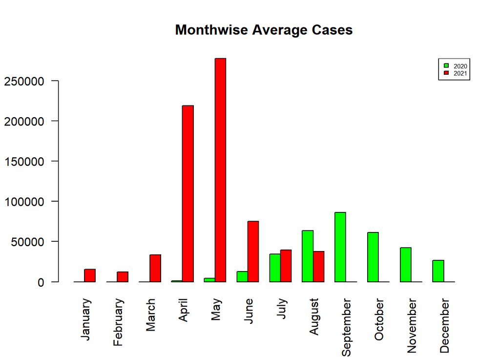

```r
df <- with(covid, aggregate(Confirmed, by = list(date(DT)), sum))
colnames(df) <- c('Date', 'Cumulative Cases')
df$Cases <- c(df$`Cumulative Cases`[1], diff(df$`Cumulative Cases`))
df$Year <- year(df$Date)
df$Month <- month(df$Date, label = TRUE, abbr = FALSE)
df_ma <- with(df, aggregate(Cases, by = list(Year, Month), mean))
rm(df)
colnames(df_ma) <- c("Year", "Month", "Average Cases")
df_ma$`Average Cases` <- round(df_ma$`Average Cases`, 0)
df_ma <- rbind(df_ma[df_ma$Year == 2020,], df_ma[df_ma$Year == 2021,])
barplot(xtabs(`Average Cases`~Year + Month, df_ma) -> tab,
        las = 2, beside = TRUE, col = c('green','red'),
        main = "Monthwise Average Cases")
legend('topright', legend = c(2020,2021), fill = c('green','red'), cex = 0.5)
```

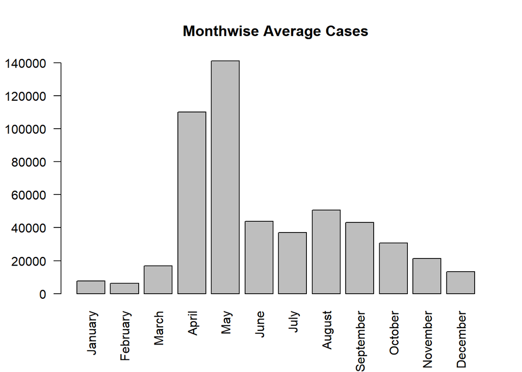

```r
barplot(apply(tab, 2, mean), las = 2, main = "Monthwise Average Cases")
```

```r
rm(df_ma)
```

#### (b) using dplyr and ggplot (try using coord_flip and coord_polar from examples & use theme function to rotate the x-axis labels to vertical or some angle)

```r
df1 <- covid |>
  mutate(year = year(DT), month = month(DT, label = TRUE, abbr = FALSE), day = day(DT)) |>
  group_by(year, month, day) |>
  summarise(cum_conf = sum(Confirmed), .groups = 'drop_last') |>
  ungroup() |>
  mutate(per_day_case = c(1, diff(cum_conf)))

knitr::kable(head(df1, n = 10), align = 'c')
```

| year | month | day | cum_conf | per_day_case |
| --- | --- | --- | --- | --- |
| 2020 | January | 30 | 1 | 1 |
| 2020 | January | 31 | 1 | 0 |
| 2020 | February | 1 | 2 | 1 |
| 2020 | February | 2 | 3 | 1 |
| 2020 | February | 3 | 3 | 0 |
| 2020 | February | 4 | 3 | 0 |
| 2020 | February | 5 | 3 | 0 |
| 2020 | February | 6 | 3 | 0 |
| 2020 | February | 7 | 3 | 0 |
| 2020 | February | 8 | 3 | 0 |

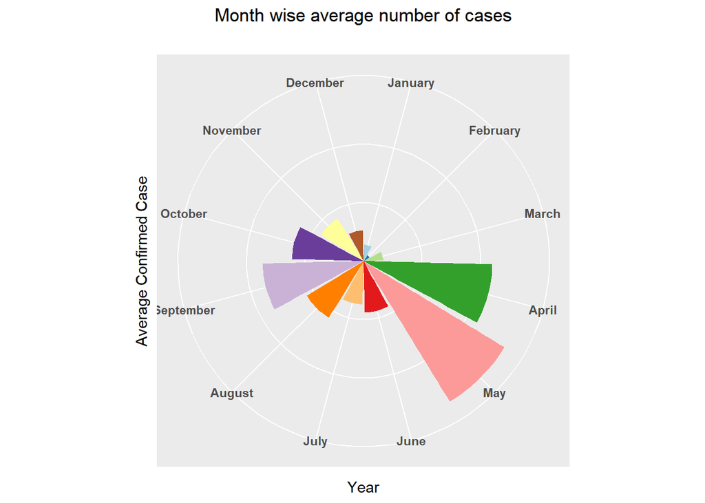

```r
# Radial plot: Average number of cases month-wise
df1 |>
  group_by(month) |>
  summarise(avg_conf = mean(per_day_case)) |>
  ggplot(aes(x = factor(month), y = avg_conf, fill = month)) +
  geom_bar(stat = 'identity') +
  coord_polar() +
  scale_fill_brewer(palette = 'Paired') +
  labs(title = "Month wise average number of cases",
       subtitle = "",
       x = "Year", y = "Average Confirmed Case", fill = "Month") +
  theme(axis.ticks.y = element_blank(),
        axis.text.y = element_blank(),
        axis.text.x = element_text(face = 'bold'),
        plot.title = element_text(hjust = 0.5),
        legend.position = 'none')
```

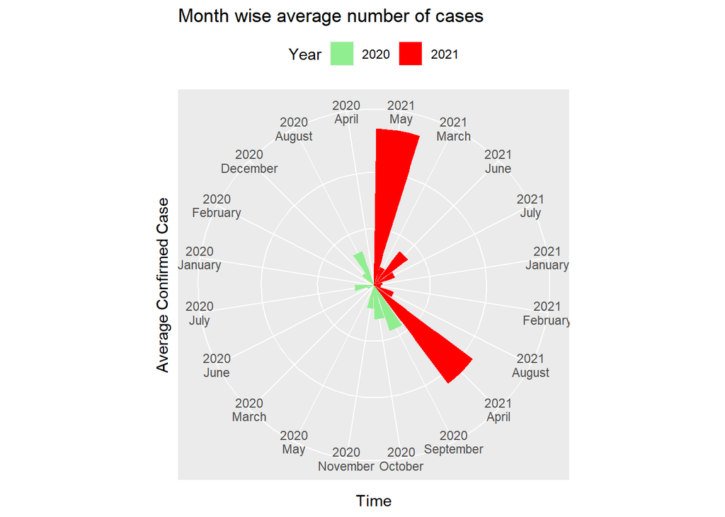

```r
# Plot: Average number of cases month-wise (year consider)
df1 |>
  group_by(year, month) |>
  summarise(avg_conf = mean(per_day_case), .groups = 'drop_last') |>
  ungroup() |>
  mutate(year_month = factor(paste(year,month,sep = '\n'))) |>
  ggplot(aes(x = year_month, y = avg_conf, fill = factor(year))) +
  geom_bar(stat = 'identity') +
  coord_polar(theta = 'x', start = 0, direction = -1) +
  scale_fill_manual(values = c('lightgreen', 'red')) +
  labs(title = "Month wise average number of cases",
       x = "Time", y = "Average Confirmed Case", fill = "Year") +
  theme(axis.ticks.y = element_blank(),
        axis.text.y = element_blank(),
        legend.position = 'top')
```

### Q5. visualize the number of confirmed cases year wise but months stacked (use format command to extract the year component or some other suitable technique before proceeding)

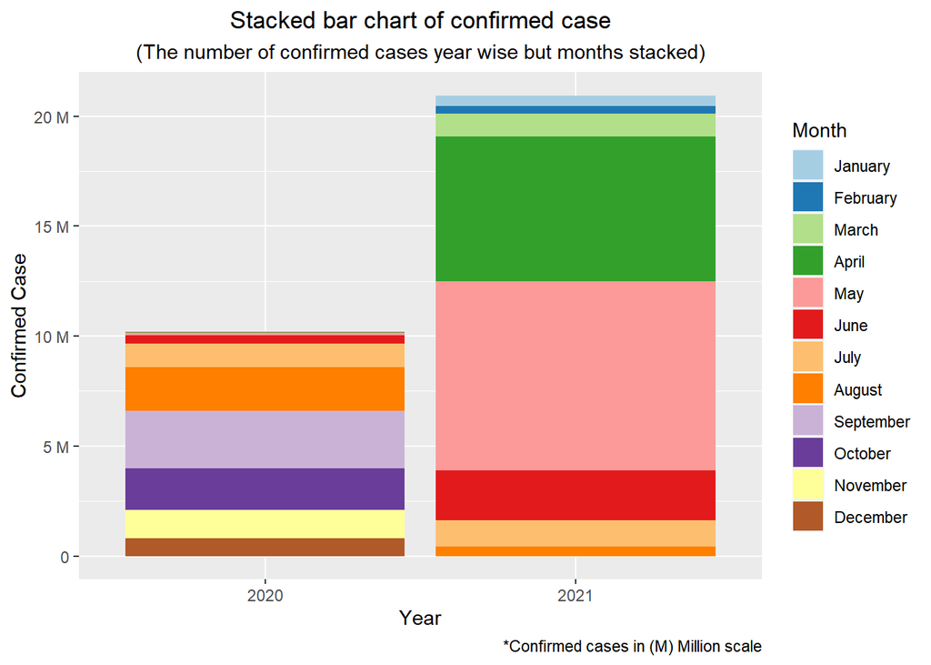

```r
df1 |>
  group_by(year, month) |>
  summarise(sum_conf = sum(per_day_case), .groups = 'drop_last') |>
  ggplot(aes(x = factor(year), y = sum_conf, fill = month)) +
  geom_bar(stat = 'identity', position = 'stack') +
  scale_fill_brewer(palette = 'Paired') +
  scale_y_continuous(breaks = seq(0,2e+07,5e+06), labels = c(0,paste(seq(5,20,5),'M'))) +
  labs(title = "Stacked bar chart of confirmed case",
       subtitle = "(The number of confirmed cases year wise but months stacked)",
       caption = '*Confirmed cases in (M) Million scale',
       x = "Year", y = "Confirmed Case", fill = "Month") +
  theme(plot.title = element_text(hjust = 0.5),
        plot.subtitle = element_text(hjust = 0.5))
```

### Q6. find state-wise the extremes in highs and lows (i.e. the largest fluctuation) in terms of cured, deaths and plot the same using ggplot

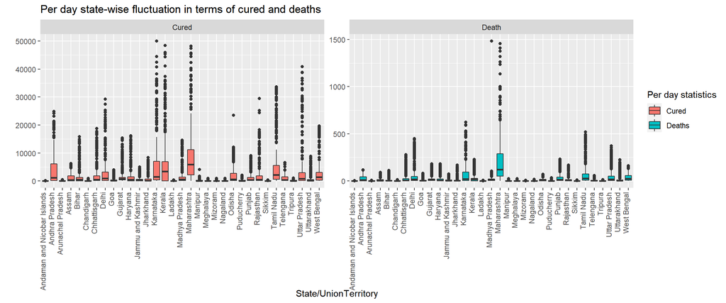

```r
df2 <- covid |>
  mutate(year = year(DT), month = month(DT, label = TRUE, abbr = FALSE), day = day(DT)) |>
  group_by(`State/UnionTerritory`) |>
  mutate(cured_per_day = c(Cured[1],diff(Cured)),
         deaths_per_day = c(Deaths[1],diff(Deaths))) |>
  select(c(1,6,7,8,9,10))
df2 |>
  filter(cured_per_day < 50000 & deaths_per_day < 1500) |>
  gather(key = 'cd', value = 'cd_per_day', 5:6) |>
  ggplot(aes(x = `State/UnionTerritory`, y = cd_per_day, fill = cd)) +
  geom_boxplot() +
  facet_wrap(~factor(cd, labels = c("Cured","Death")), scales = "free_y") +
  labs(y = '', title = "Per day state-wise fluctuation in terms of cured and deaths") +
  scale_fill_discrete(name = 'Per day statistics', labels = c('Cured', 'Deaths')) +
  theme(axis.text.x = element_text(angle = 90, hjust = 1, vjust = 0))
```

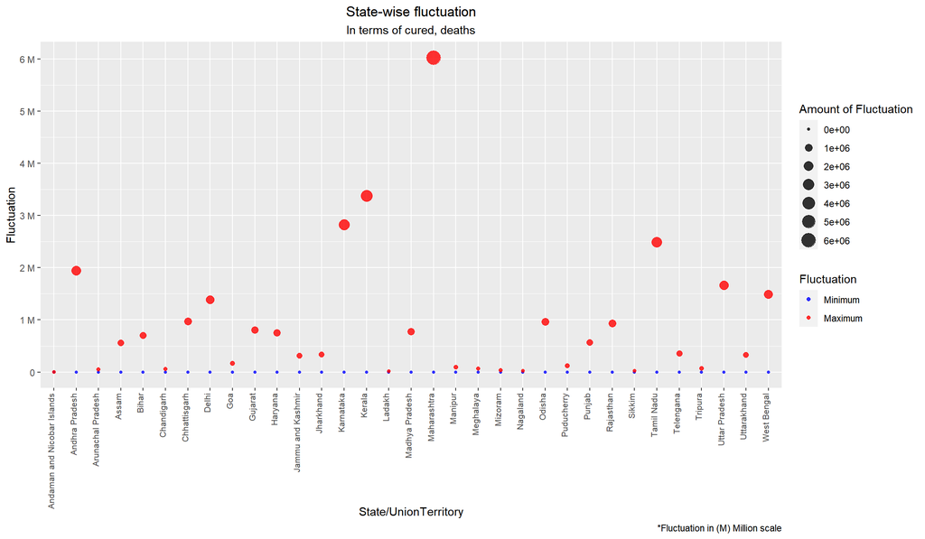

```r
covid |>
  select(`State/UnionTerritory`, Cured, Deaths) |>
  group_by(`State/UnionTerritory`) |>
  summarise(min_fluc = min(abs(Cured - Deaths)),
            max_fluc = max(abs(Cured - Deaths))) |>
  gather("variable", "value", -`State/UnionTerritory`) |>
  ggplot(aes(x = `State/UnionTerritory`, y = value)) +
  geom_point(aes(col = variable, size = value), alpha = 0.8) +
  scale_y_continuous(breaks = seq(0,6e+06,1e+06), labels = c(0,paste(1:6, 'M'))) +
  labs(title = "State-wise fluctuation",
       subtitle = "In terms of cured, deaths",
       caption = '*Fluctuation in (M) Million scale',
       y = "Fluctuation", col = "Fluctuation", size = "Amount of Fluctuation") +
  scale_color_manual(values = c('blue','red'), breaks = c("min_fluc","max_fluc"), labels = c("Minimum", 'Maximum')) +
  theme(plot.title = element_text(hjust = 0.5),
        plot.subtitle = element_text(hjust = 0.5),
        axis.text.x = element_text(angle = 90, size = 8, hjust = 1, vjust = 0))
```

[figure not shown]

```r
covid |>
  select(`State/UnionTerritory`, Cured, Deaths) |>
  group_by(`State/UnionTerritory`) |>
  summarise(min_fluc = min(abs(Cured - Deaths)),
            max_fluc = max(abs(Cured - Deaths))) |>
  gather("key", "value", -`State/UnionTerritory`) |>
  arrange(`State/UnionTerritory`) |>
  mutate(pair = rep(1:(n()/2), each = 2), key = factor(key, labels = c("Minimum", 'Maximum'))) |>
  ggplot(aes(y = `State/UnionTerritory`, x = value)) +
  geom_line(aes(group = pair), size = 1) +
  geom_point(aes(col = key), size = 4) +
  scale_x_continuous(breaks = seq(0,6e+06,1e+06), labels = c(0,paste(1:6, 'M'))) +
  labs(title = "State-wise fluctuation",
       subtitle = "In terms of cured, deaths",
       caption = '*Fluctuation in (M) Million scale',
       x = "Fluctuation", y = "State/Union Territory",
       col = "Fluctuation", size = "Amount of Fluctuation") +
  theme(plot.title = element_text(hjust = 0.5),
        plot.subtitle = element_text(hjust = 0.5))
```

### Q7. find the number of cases per month (or per quarter) and year wise (Hint: explore months, quarters and format functions)

```r
df1 |>
  group_by(year, month) |>
  summarise(per_month_case = sum(per_day_case))
```

| year | month | per_month_case |
| --- | --- | --- |
| 2020 | January | 1 |
| 2020 | February | 2 |
| 2020 | March | 1353 |
| 2020 | April | 31934 |
| 2020 | May | 143047 |
| 2020 | June | 382354 |
| 2020 | July | 1076609 |
| 2020 | August | 1977660 |
| 2020 | September | 2595024 |
| 2020 | October | 1904089 |

[output cut: 10 more lines]

```r
df1 |>
  group_by(year, quarter = quarter(make_date(year, month, day))) |>
  summarise(per_quarter_case = sum(per_day_case))
```

| year | quarter | per_quarter_case |
| --- | --- | --- |
| 2020 | 1 | 1356 |
| 2020 | 2 | 557335 |
| 2020 | 3 | 5649293 |
| 2020 | 4 | 4000201 |
| 2021 | 1 | 1873470 |
| 2021 | 2 | 17436323 |
| 2021 | 3 | 1638647 |

### Q8. plot the data in Q7 using an appropriate plot - scatter

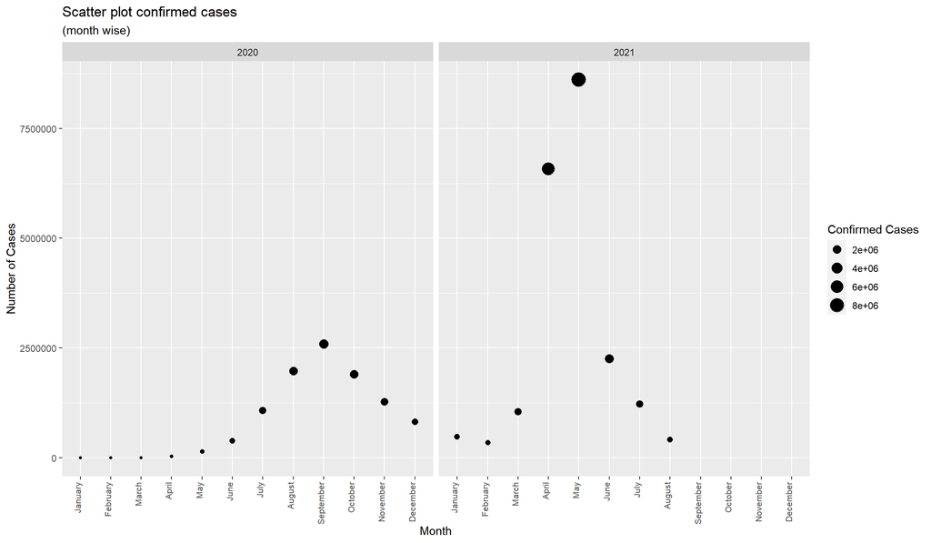

```r
df1 |>
  group_by(year, month) |>
  summarise(per_month_case = sum(per_day_case), .groups = 'drop_last') |>
  ggplot(aes(x = month, y = per_month_case)) +
  geom_point(aes(size = per_month_case)) +
  facet_wrap(~year) +
  theme(axis.text.x = element_text(angle = 90, size = 8, hjust = 1, vjust = 0)) +
  labs(title = "Scatter plot confirmed cases",
       subtitle = "(month wise)",
       x = "Month", y = "Number of Cases", size = "Confirmed Cases")
```

### Q9. find the correlation of the no. of Cured and Deaths column after grouping it year and month wise

```r
df2 |>
  group_by(year, month) |>
  summarise(correlation = cor(cured_per_day, deaths_per_day)) |>
  slice(-c(1,2))
```

| year | month | correlation |
| --- | --- | --- |
| 2020 | March | 0.2215863 |
| 2020 | April | 0.4612021 |
| 2020 | May | 0.6120761 |
| 2020 | June | 0.4522843 |
| 2020 | July | 0.7990455 |
| 2020 | August | 0.8547858 |
| 2020 | September | 0.8601462 |
| 2020 | October | 0.8185104 |
| 2020 | November | 0.7783175 |
| 2020 | December | 0.8103487 |

[output cut: 6 more lines]

### Q10. create line plots of no. of infections per day for different states

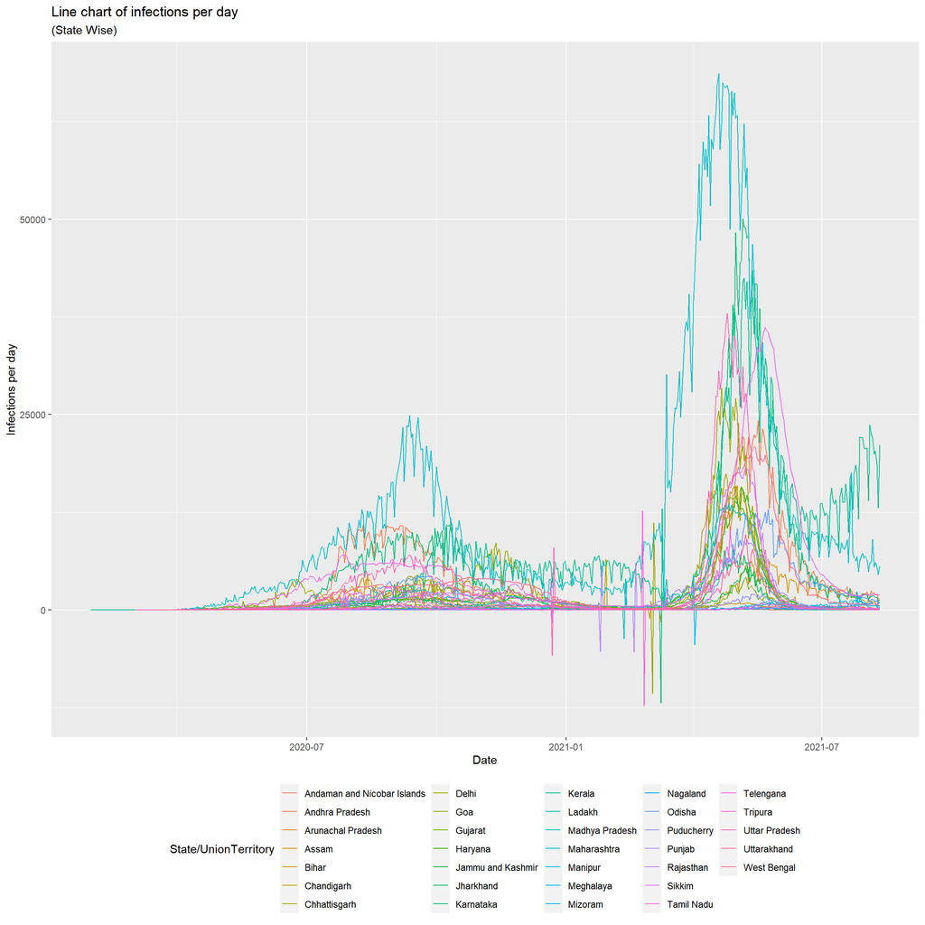

```r
df3 <- covid |>
  group_by(`State/UnionTerritory`) |>
  summarise(Date = date(DT),
            per_day_case = c(Confirmed[1], diff(Confirmed)), .groups = 'drop_last')
df3 |>
  ggplot(aes(x = Date, y = per_day_case, col = `State/UnionTerritory`)) +
  geom_line() +
  labs(x = "Date", y = "Infections per day",
       title = "Line chart of infections per day",
       subtitle = "(State Wise)") +
  theme(strip.background = element_rect(fill = 'black'),
        strip.text = element_text(colour = 'yellow', size = 8, face = 'bold'),
        legend.position = 'bottom')
```

### Q11. if you find the plot in Q10 too messy try to filter based on states in alphabetical order e.g. states starting with A,B,C,D,E in one plot those starting with F,G,H, etc in second plot and so on.

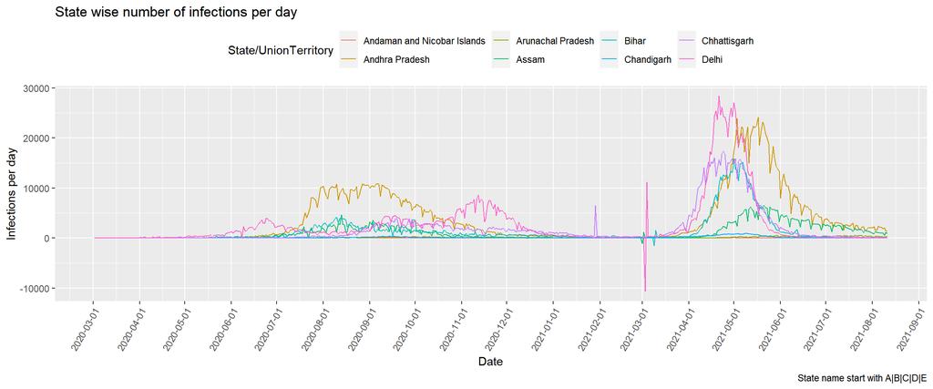

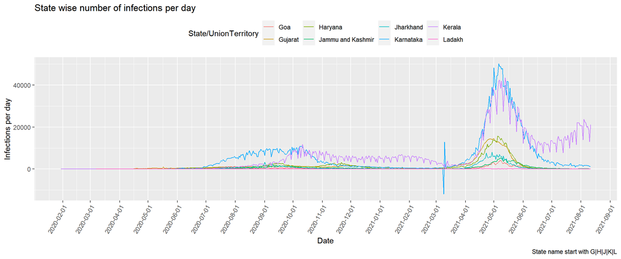

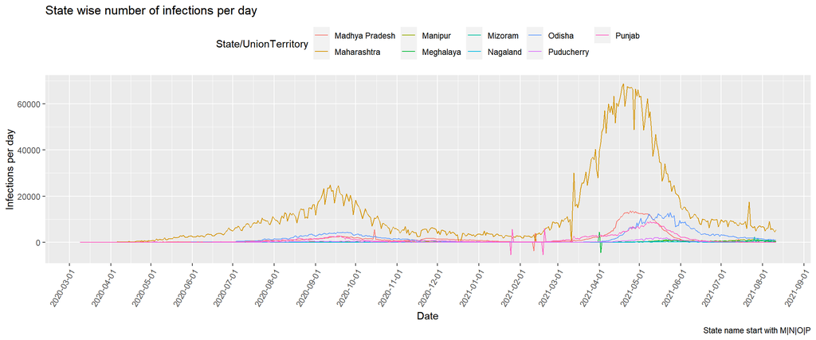

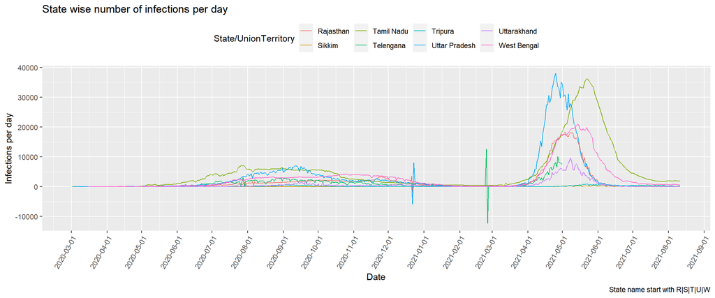

```r
plot_by_lettter <- function(str_start_with){
  df3 |>
    filter(str_detect(substr(as.character(`State/UnionTerritory`),1,1),
                      as.character(str_start_with), negate = F)) |>
    ggplot(aes(x = Date, y = per_day_case, col = `State/UnionTerritory`)) +
    geom_line() +
    scale_x_date(date_breaks = '1 month') +
    labs(x = "Date", y = "Infections per day",
         title = "State wise number of infections per day",
         caption = paste("State name start with", str_start_with)) +
    theme(legend.position = "top",
          axis.text.x = element_text(angle = 60, hjust = 1))
}
lapply(list("A|B|C|D|E","G|H|J|K|L", "M|N|O|P", "R|S|T|U|W"), plot_by_lettter)
```

#### i. direct substitution with multiple assignment operators

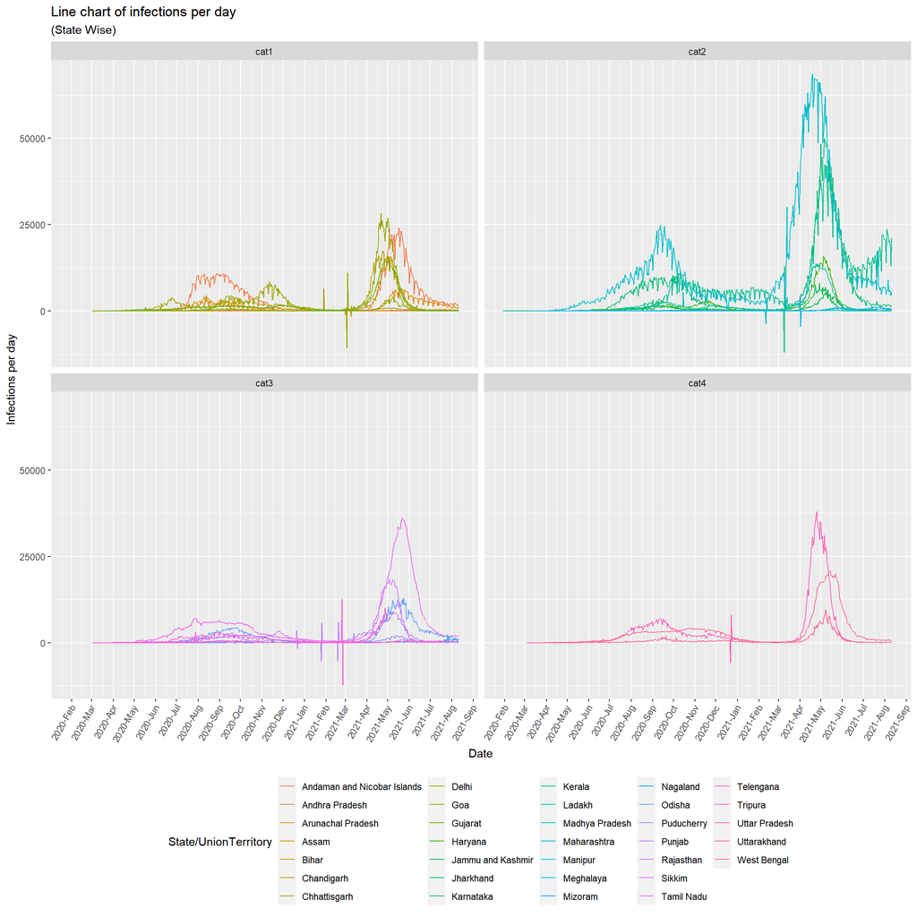

```r
df3$category <- c(rep('cat1', sum(df3$`State/UnionTerritory` %in% unique(df3$`State/UnionTerritory`)[1:10])),
                  rep('cat2', sum(df3$`State/UnionTerritory` %in% unique(df3$`State/UnionTerritory`)[11:20])),
                  rep('cat3', sum(df3$`State/UnionTerritory` %in% unique(df3$`State/UnionTerritory`)[21:30])),
                  rep('cat4', sum(df3$`State/UnionTerritory` %in% unique(df3$`State/UnionTerritory`)[31:33])))
df3 |>
  ggplot(aes(x = Date, y = per_day_case, col = `State/UnionTerritory`)) +
  geom_line() +
  scale_x_date(date_labels = format("%Y-%b"), date_breaks = '1 month') +
  facet_wrap(~category) +
  labs(x = "Date", y = "Infections per day",
       title = "Line chart of infections per day",
       subtitle = "(State Wise)") +
  theme(axis.text.x = element_text(angle = 60, hjust = 1.2, vjust = 1.2),
        legend.position = 'bottom')
```

#### ii. custom function and call it using mapply (w/ or w/o dplyr)

[figure not shown]

```r
c_fun <- function(x){
  ifelse(x %in% state_to_be_stay[1:10], 'cat1',
         ifelse(x %in% state_to_be_stay[11:20], 'cat2',
                ifelse(x %in% state_to_be_stay[21:30], 'cat3',
                       ifelse(x %in% state_to_be_stay[31:33], 'cat4'))))
}

df3$category <- mapply(c_fun, df3$`State/UnionTerritory`)
df3 |>
  ggplot(aes(x = Date, y = per_day_case, col = `State/UnionTerritory`)) +
  geom_line() +
  scale_x_date(date_labels = format("%Y-%b"), date_breaks = '1 month') +
  facet_wrap(~category) +
  labs(x = "Date", y = "Infections per day",
       title = "Line chart of infections per day",
       subtitle = "(State Wise)") +
  theme(axis.text.x = element_text(angle = 60, hjust = 1.2, vjust = 1.2),
        legend.position = 'bottom')
```

### Q13. plot the fluctuations of per day confirmed cases statewise, order by amount of fluctuations (Hint: use IQR) hint: use boxplot

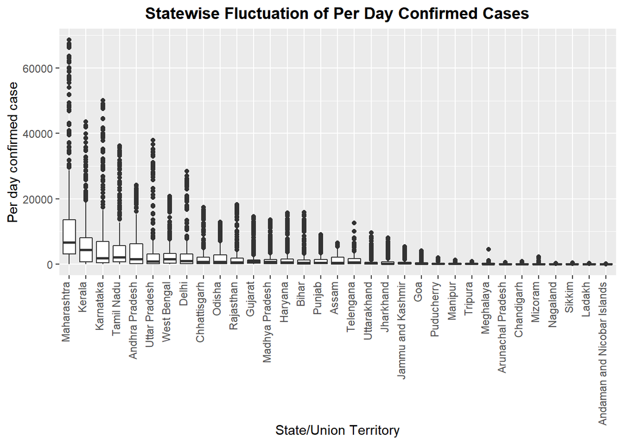

```r
covid |>
  group_by(`State/UnionTerritory`) |>
  summarise(per_day_conf = c(Confirmed[1], diff(Confirmed)), .groups = 'drop_last') |>
  ungroup() |>
  filter(per_day_conf > 0) |>
  ggplot(aes(x = reorder(`State/UnionTerritory`, -per_day_conf), y = per_day_conf)) +
  geom_boxplot() +
  labs(x = 'State/Union Territory', y = 'Per day confirmed case',
       title = "Statewise Fluctuation of Per Day Confirmed Cases") +
  theme(axis.text.x = element_text(angle = 90, hjust = 1, vjust = 0),
        plot.title = element_text(hjust = 0.5, face = 'bold'))
```

### Q14. create a fluctuations (IQR) based 4 categories and plot them using geom_jitter

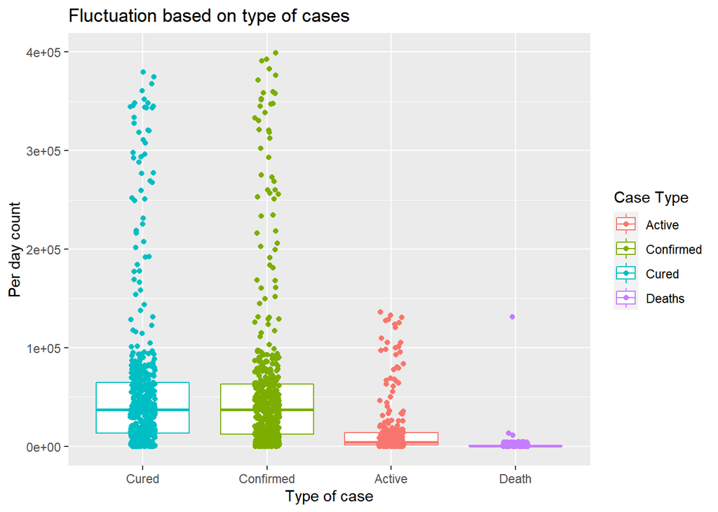

```r
covid |>
  group_by(Date = as.Date(DT)) |>
  summarise(cum_conf = sum(Confirmed),
            cum_cured = sum(Cured),
            cum_deaths = sum(Deaths), .groups = 'drop_last') |>
  ungroup() |>
  mutate(per_day_conf = c(cum_conf[1], diff(cum_conf)),
         per_day_deaths = c(cum_deaths[1], diff(cum_deaths)),
         per_day_cured = c(cum_cured[1], diff(cum_cured)),
         per_day_active = per_day_conf - (per_day_cured + per_day_deaths)) |>
  select(-c(2,3,4)) |>
  gather(key = 'cdc', value = 'per_day_value', 2:5) |>
  filter(per_day_value > 0 & per_day_value < 4e+05) |>
  ggplot(aes(x = reorder(cdc, -per_day_value), y = per_day_value, col = factor(cdc))) +
  geom_boxplot(outlier.shape = NA, coef = 0) + geom_jitter(width = 0.1) +
  scale_color_discrete(labels = c('Active', 'Confirmed', 'Cured', 'Deaths')) +
  scale_x_discrete(labels = c('Cured', 'Confirmed', 'Active', 'Death')) +
  labs(x = "Type of case", y = "Per day count",
       title = "Fluctuation based on type of cases", col = "Case Type")
```

### Q15. find the relationship between Confirmed cases per day and deaths per day where the confirmation is a positive number

[figure not shown]

```r
covid |>
  group_by(Date = as.Date(DT)) |>
  summarise(cum_conf = sum(Confirmed),
            cum_deaths = sum(Deaths), .groups = 'drop_last') |>
  ungroup() |>
  mutate(per_day_conf = c(cum_conf[1], diff(cum_conf)),
         per_day_deaths = c(cum_deaths[1], diff(cum_deaths))) |>
  select(-c(2,3)) |>
  filter((per_day_conf  > 0  & per_day_conf  < 100000 )) |>
  ggplot(aes(x = per_day_conf, y = per_day_deaths)) +
  geom_point(size = 1) +
  labs(y = "Per day confirmed cases", y = "Per day deaths",
       title = "Scatter plot of per day confirmed and death case",
       caption = '*Three outliers are deleted') +
  theme(plot.title = element_text(hjust = 0.5, face = 'bold'))
```

### Q16. find the relationship between deaths per day, confirmed per day, cured per day in a time series plot

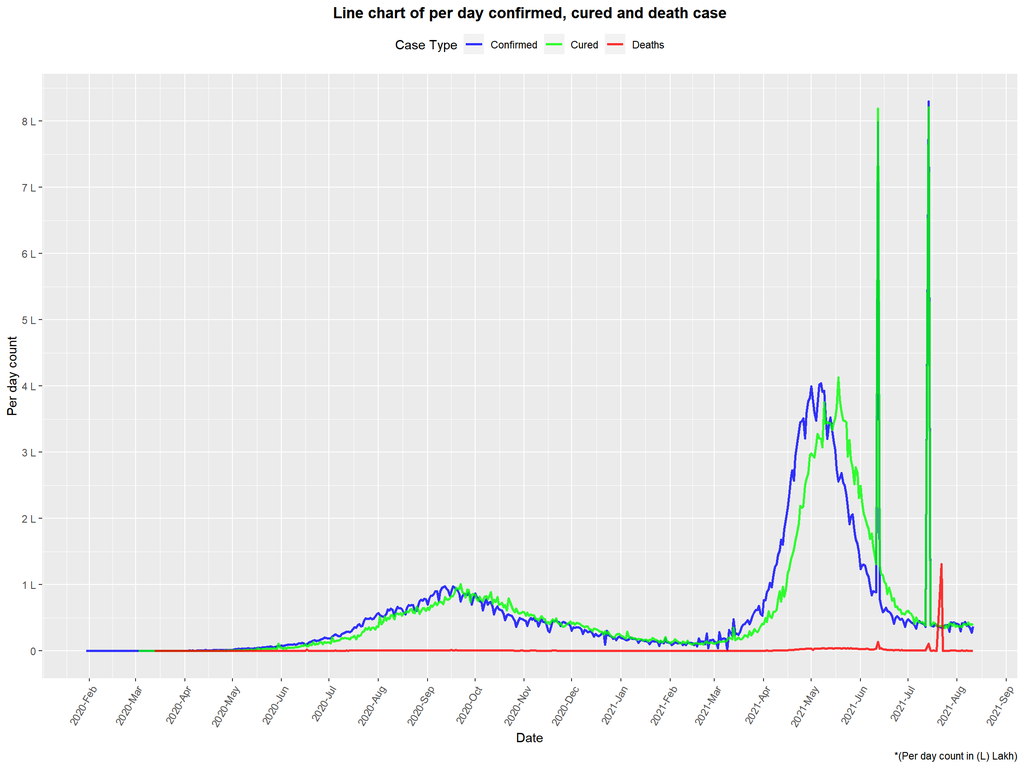

```r
covid |>
  group_by(Date = as.Date(DT)) |>
  summarise(cum_conf = sum(Confirmed),
            cum_cured = sum(Cured),
            cum_deaths = sum(Deaths), .groups = 'drop_last') |>
  ungroup() |>
  mutate(per_day_conf = c(cum_conf[1], diff(cum_conf)),
         per_day_deaths = c(cum_deaths[1], diff(cum_deaths)),
         per_day_cured = c(cum_cured[1], diff(cum_cured))) |>
  select(-c(2,3,4)) |>
  gather(key = 'cdc', value = 'per_day_value', 2:4) |>
  filter(per_day_value > 0 & per_day_value < 2e+06) |>
  ggplot(aes(x = Date, y = per_day_value, col = cdc)) +
  geom_line(size = 1, alpha = 0.8) +
  labs(y = "Per day count",
       title = "Line chart of per day confirmed, cured and death case",
       color = "Case Type",
       caption = '*(Per day count in (L) Lakh)') +
  scale_x_date(date_labels = format("%Y-%b"), date_breaks = '1 month') +
  scale_y_continuous(breaks = seq(0,800000,100000), labels = c(0, paste(1:8, 'L'))) +
  scale_color_manual(values = c('blue','green','red'),
                     labels = c('Confirmed','Cured','Deaths')) +
  theme(axis.text.x = element_text(angle = 60, hjust = 1),
        legend.position = 'top',
        plot.title = element_text(hjust = 0.5, face = 'bold'))
```

### Q17. Frame 4 more interesting questions and plot them using appropriate plots.

#### Q1

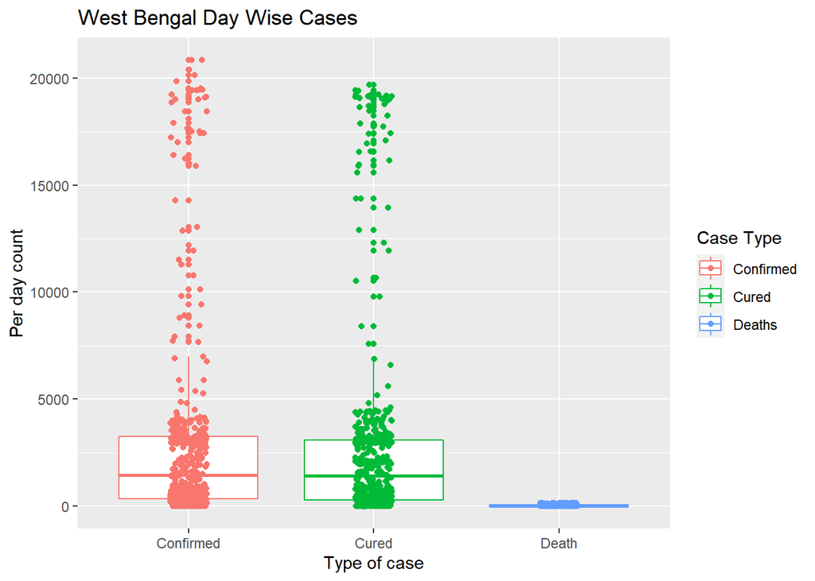

```r
# Q1: Distribution of west bengal cases
covid |>
  filter(`State/UnionTerritory` == 'West Bengal') |>
  mutate(per_day_conf = c(Confirmed[1], diff(Confirmed)),
         per_day_deaths = c(Deaths[1], diff(Deaths)),
         per_day_cured = c(Cured[1], diff(Cured))) |>
  select(-c(1:5)) |>
  gather(key = 'cdc', value = 'per_day_value', 1:3) |>
  ggplot(aes(x = reorder(cdc, -per_day_value), y = per_day_value, col = factor(cdc))) +
  geom_boxplot() + geom_jitter(width = 0.1) +
  scale_color_discrete(labels = c('Confirmed', 'Cured', 'Deaths')) +
  scale_x_discrete(labels = c('Confirmed', 'Cured', 'Death')) +
  labs(x = "Type of case", y = "Per day count",
       title = "West Bengal Day Wise Cases", col = "Case Type")
```

#### Q2

```r
# Study of Top 5 Highest affected states
covid$DT |> tail()
```

```
## [1] "2021-08-11 08:00:00 IST" "2021-08-11 08:00:00 IST"
## [3] "2021-08-11 08:00:00 IST" "2021-08-11 08:00:00 IST"
## [5] "2021-08-11 08:00:00 IST" "2021-08-11 08:00:00 IST"
```

```r
top_5 <- covid |>
  mutate(Date = as.Date(DT)) |>
  filter(Date == "2021-08-11") |>
  arrange(desc(Confirmed)) |>
  head(5)
as.vector(top_5$`State/UnionTerritory`)
```

```
## [1] "Maharashtra"    "Kerala"         "Karnataka"      "Tamil Nadu"
## [5] "Andhra Pradesh"
```

#### Q3 & Q4

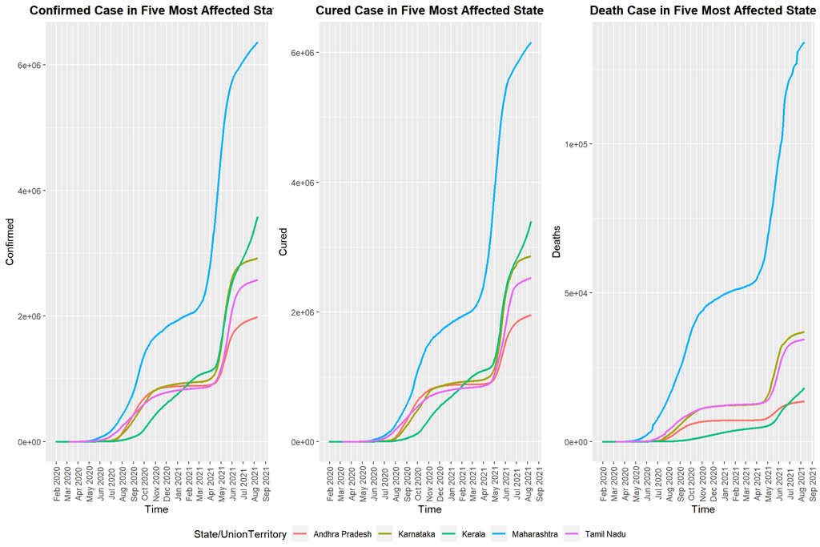

```r
my_theme <- theme(axis.text.x = element_text(angle = 90, vjust = 0.5),
                  plot.title = element_text(face = "bold", hjust = 0.5))
# Plot Confirmed cases
conf <- covid |>
  filter(`State/UnionTerritory` %in% top_5$`State/UnionTerritory`) |>
  group_by(`State/UnionTerritory`) |>
  ggplot(aes(x = as.Date(DT), y = Confirmed, col = `State/UnionTerritory`)) +
  geom_line(size = 1) +
  scale_x_date(date_breaks = '1 month', date_labels = "%b %Y") +
  labs(x = "Time",
       title = "Confirmed Case in Five Most Affected State") +
  my_theme

# Plot Cured cases
cured <- covid |>
  filter(`State/UnionTerritory` %in% top_5$`State/UnionTerritory`) |>
  group_by(`State/UnionTerritory`) |>
  ggplot(aes(x = as.Date(DT), y = Cured, col = `State/UnionTerritory`)) +
  geom_line(size = 1) +
  scale_x_date(date_breaks = '1 month', date_labels = "%b %Y") +
  labs(x = "Time",
       title = "Cured Case in Five Most Affected State") +
  my_theme


# Plot Deaths cases
death <- covid |>
  filter(`State/UnionTerritory` %in% top_5$`State/UnionTerritory`) |>
  group_by(`State/UnionTerritory`) |>
  ggplot(aes(x = as.Date(DT), y = Deaths, col = `State/UnionTerritory`)) +
  geom_line(size = 1) +
  scale_x_date(date_breaks = '1 month', date_labels = "%b %Y") +
  labs(x = "Time",
       title = "Death Case in Five Most Affected State") +
  my_theme
ggpubr::ggarrange(conf, cured, death, ncol = 3, common.legend = TRUE, legend = "bottom")
```